# A Comprehensive Profit Evaluation of Modern Cinema

Author

Matt Schneider, Liam Boyd

Published

December 7, 2024

## Question to Answer:

When assuming an unlimited access to investment funds and planning to produce a movie, what factors represent profitability? What should be considered when picking what style of movie you should create?

## Summary

- Through clustering analysis, the ideal movie to invest in is a mid-budget film to maximize profits. This minimizes the risk involved with low-budget films, and generally produces higher overall profits relative to the budget spent on production when compared to high-budget films.
- Through careful analysis, we have found that there is little correlation between a movie’s profit ratio, genre, post-production ratings and seasonal release date. These imply that a producer may choose to tailor their film to personal preference and potentially put more of a focus on the ideal cast involved.
- There are many external factors not considered in our analysis to maximize profits. This generally stems from inaccessible data, and other qualitative factors that audiences consider such as brand loyalty and movie marketing.

## Analysis

### Clustering Analysis

Through clustering analysis we first use the elbow method to determine the ideal amount of clusters. For each k value we calculate the within-cluster sum of squares (WCSS), and plot it to determine the ideal k where there is a marginal change in WCSS. The ideal number of clusters according to our graph is ~3, implying that there are three distinct groups in our data set with clear differences in budget, run time, and profitability.

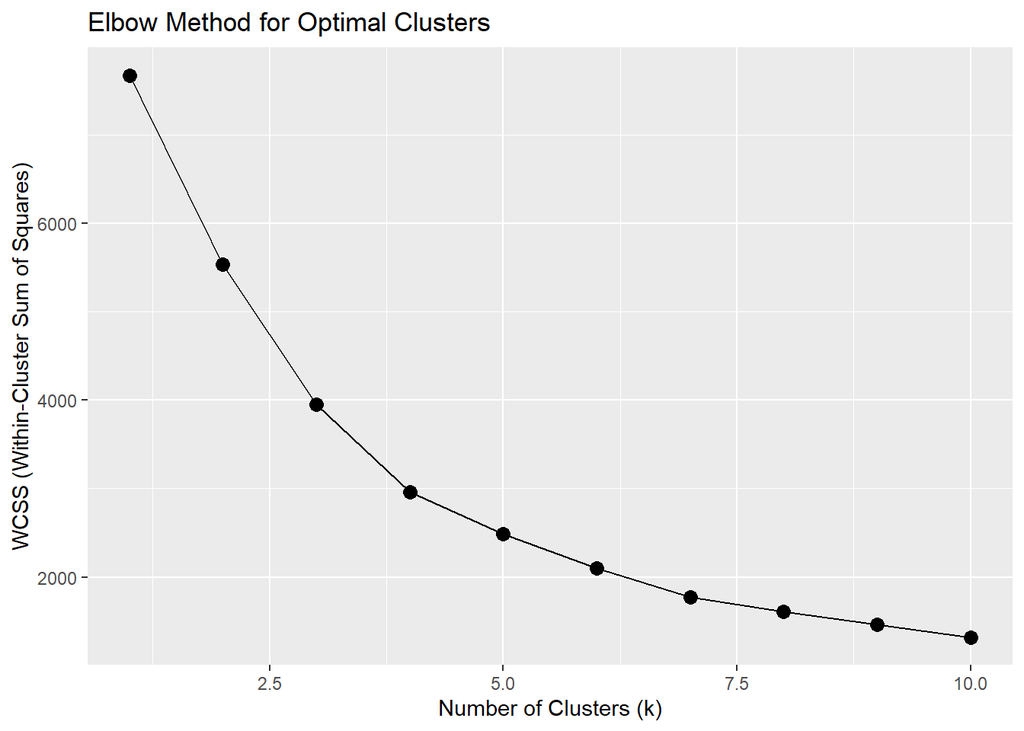

**Cluster 1:**

- Lowest budget films have the greatest variation in profitability though the average budget of $4.6M returns an average profit of (44.7x) return. This means that this cluster can be highly profitable despite the smaller scale productions.
- This cluster has the smallest amount of movies produced, showing that these films are rare but can be extremely financially successful.
- The variation seen on the graph demonstrates the high risk involved due to the large spread of films having many different results when similar budgets and run times are considered.

**Cluster 2:**

- This group represents high-budget films with an average budget of $133M and the longest average run times (135 minutes).
- This is the lowest profit ratio (2.4x) of the three clusters, indicating that these films are likely higher risk, high investment projects that yield lower returns.
- Considering that there are nearly 600 movies in this data set, this indicates that many high-budget films struggle to achieve significant profits.

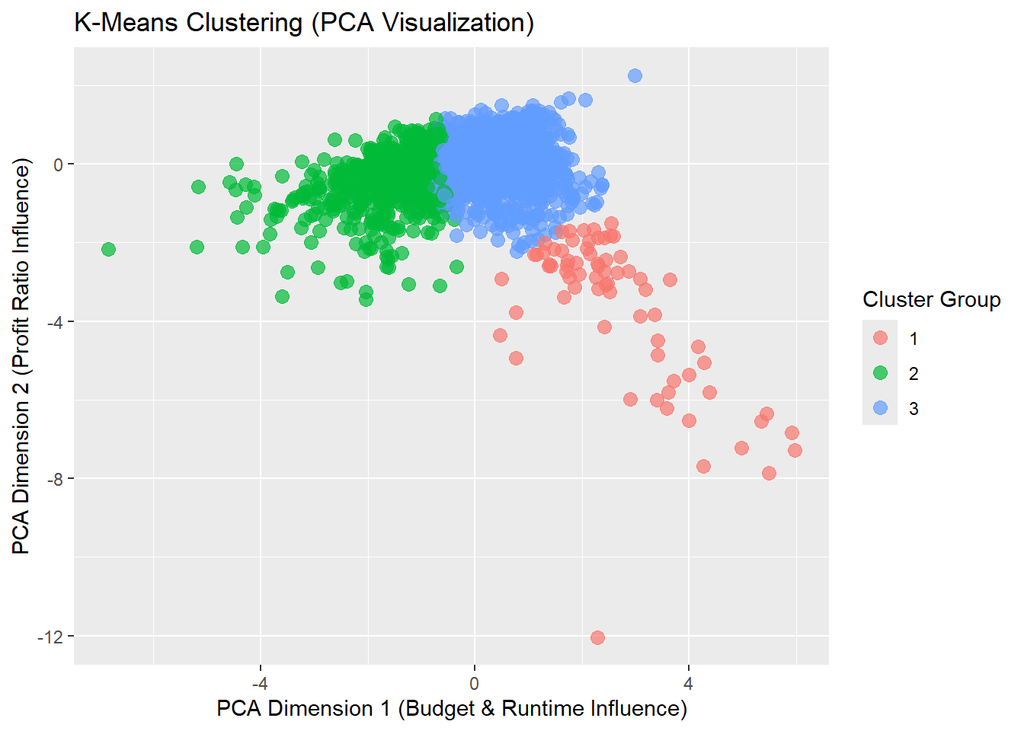

Clustering Analysis for Ideal Budget and Runtime

| Cluster | Average Budget | Average Runtime | Average Profit Ratio | Count |
| --- | --- | --- | --- | --- |
| 1 | 4,604,648 | 113 | 44.7 | 72 |
| 2 | 132,607,007 | 135 | 2.4 | 597 |
| 3 | 32,569,099 | 107 | 3.5 | 1889 |

### Movie Genre Significance

As seen by our analysis above, budget does have an effect on the profitability of a movie. Is there any other factors that we could include in our best model of predicting profit ratio with the data available? We ran a PCA analysis on genre and concluded the following.

Limited Predictive Power of Genres: The first principle component (PC1), which represents the most significant variation in genres, showed a very weak correlation with ProfitRatio (r = 0.0178). This suggests that genres contribute minimally to explaining or predicting movie profitability.

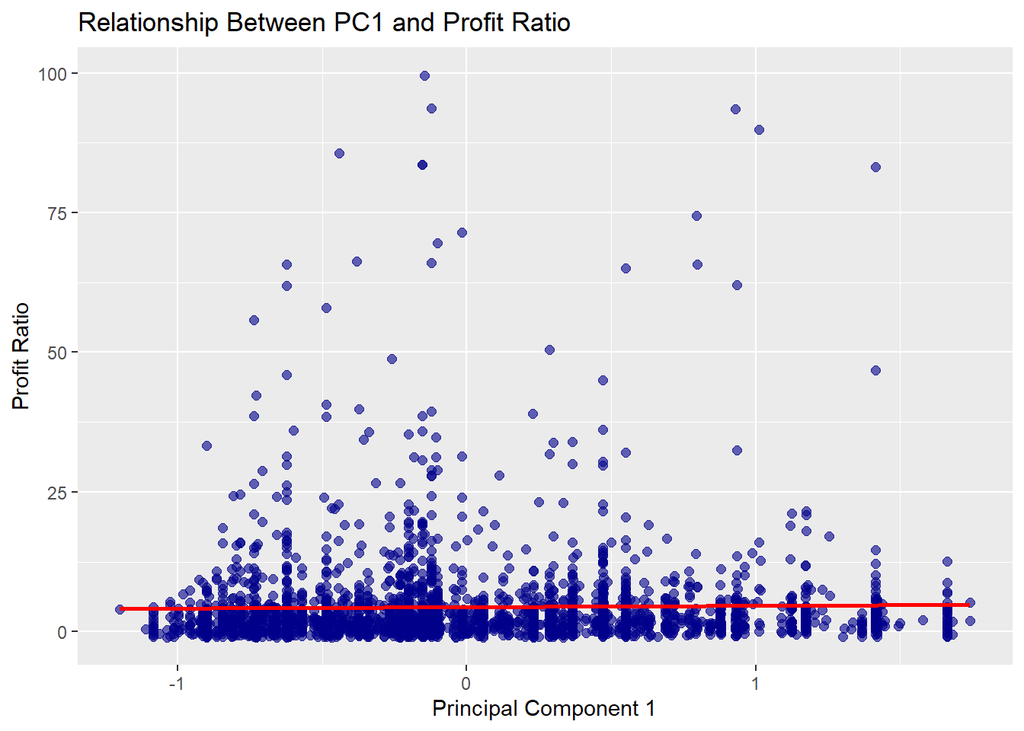

Correlation Between PC1 and Profit Ratio

| Metric | Value |
| --- | --- |
| Correlation between PC1 and Profit Ratio | 0.0178 |

### Seasonality Regression

Through a simple linear regression model, it can be noticed that there is no significance on the release date of the movie throughout the year.

- Each coefficient has a high p-value, showing that none of the seasons are significant factors of a movie’s profitability.
- The low R-Squared value represents that the release date represents nearly 0% of variance in profit ratio.

Effect of Season on Profit Ratio

| Season | Estimate | Std. Error | t value | Pr(>\|t\|) |
| --- | --- | --- | --- | --- |
| (Intercept) | 4.173 | 0.329 | 12.687 | 0.000 |
| SeasonSpring | 0.248 | 0.492 | 0.505 | 0.614 |
| SeasonSummer | −0.039 | 0.457 | −0.085 | 0.932 |
| SeasonWinter | 0.811 | 0.493 | 1.646 | 0.100 |

$$\text{Adjusted R-Squared} = 0.0003$$

### Effect of Budget and Rating on Profit Ratio

#### Budget and Rating

Running a normalized linear regression shows that budget explains more variance than rating, but both are significant. The regression shows similar results to the cluster analysis, that when budget increases, profitability decreases. For rating, it shows that higher-rated movies are more likely to achieve higher profitability.

However, the variance this model explains is low likely due to the complexity of variables involved that make up a movies profitability that are difficult to include.

Linear Regression Results (Normalized)

Significance of Budget and Rating

| Predictor | Coefficient | Std. Error | t-Statistic | P-Value | Significance |
| --- | --- | --- | --- | --- | --- |
| (Intercept) | 4.393 | 0.165 | 26.670 | 0.000 | *** |
| Budget | −1.655 | 0.165 | −10.028 | 0.000 | *** |
| Rating | 1.650 | 0.165 | 10.000 | 0.000 | *** |

Incremental R-squared by Predictor

Contribution of Each Predictor to R-squared

| Predictor | Incremental R-squared |
| --- | --- |
| Budget | 0.040 |
| Rating | 0.036 |

#### Attempting to explain more variance

We used a decision tree model to capture non-linear relationships, aiming to achieve a higher R^2 value. This approach explained a greater variance and reinforced that budget is a more significant determinant of profit ratio than rating.

The decision tree shows that most movies cluster in the lower profit ratio categories, consistent with our prior clustering analysis. Budget serves as the primary threshold for dividing profit ratios, with ratings playing a secondary role. Higher-rated movies tend to achieve higher profit ratios, but these effects are more pronounced within specific budget ranges.

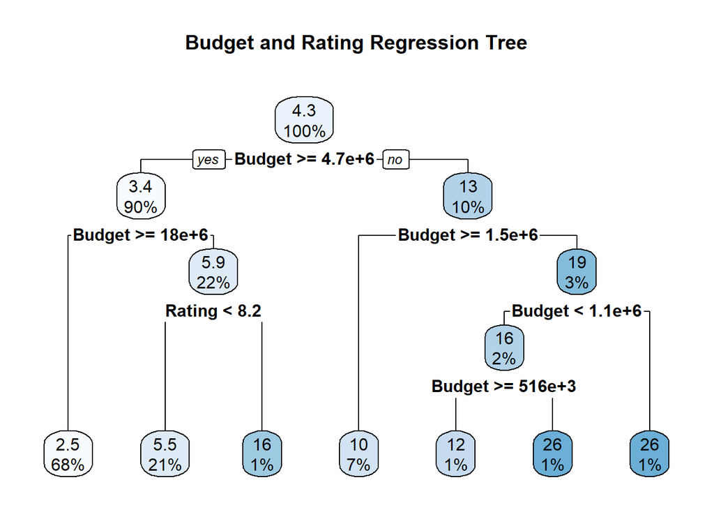

Decision Tree Performance Metrics

Regression Tree - Budget and Rating

| Metric | .estimator | Value | Explanation |
| --- | --- | --- | --- |
| rmse | standard | 10.476 | Root Mean Square Error |
| rsq | standard | 0.203 | R-squared |
| mae | standard | 4.416 | Mean Absolute Error |

## Abundant Issues with Movie Data

1. Key metrics aren’t publicly available:
   - Some alternative factors such as the marketing budget would most likely have a key impact on profitability, as even if a movie’s budget and revenue are present (~70% of data set). A movie’s official budget primarily includes the costs involved with making the film. Traditionally the average movie marketing budget represents another 50% of the production costs, representing a significant factor left unconsidered in our analysis.
2. Complexity of Success factors:
   - There are many qualitative factors involved in a movie’s success including “star power” from the cast involved, franchise loyalty, word of mouth, movie memorability, etc.
3. Difficulty of analysis on cast and directors:
   - Cast and director analysis may be a significant factor, though the complexity of a regression model on the entirely of the production team involved would require significant computing power over a large data set.
4. Limited revenue representation:
   - Other forms of revenue such as streaming revenue or product sales are not considered in the official revenue posted online. Our data-set’s “revenue” represents purely box office earnings.